# Principal Component Analysis with Cancer Data

# Q4. Perform bi variate analysis including correlation, pairplots and state the inferences.

|  | ClumpThickness | Cell Size | Cell Shape | Marginal Adhesion | Single Epithelial Cell Size | Bare Nuclei | Normal Nucleoli | Bland Chromatin | Mitoses | Class |
| --- | --- | --- | --- | --- | --- | --- | --- | --- | --- | --- |
| ClumpThickness | 1.000000 | 0.578156 | 0.588956 | 0.383573 | 0.432165 | 0.507318 | 0.496158 | 0.450853 | 0.296797 | 0.675748 |
| Cell Size | 0.578156 | 1.000000 | 0.877404 | 0.640096 | 0.689982 | 0.588370 | 0.712986 | 0.657170 | 0.403911 | 0.757623 |
| Cell Shape | 0.588956 | 0.877404 | 1.000000 | 0.612415 | 0.649388 | 0.615732 | 0.687331 | 0.654724 | 0.381645 | 0.757932 |
| Marginal Adhesion | 0.383573 | 0.640096 | 0.612415 | 1.000000 | 0.528163 | 0.588980 | 0.611294 | 0.514134 | 0.358434 | 0.622371 |
| Single Epithelial Cell Size | 0.432165 | 0.689982 | 0.649388 | 0.528163 | 1.000000 | 0.480300 | 0.554625 | 0.558757 | 0.434875 | 0.604709 |
| Bare Nuclei | 0.507318 | 0.588370 | 0.615732 | 0.588980 | 0.480300 | 1.000000 | 0.604511 | 0.473021 | 0.263276 | 0.756155 |
| Normal Nucleoli | 0.496158 | 0.712986 | 0.687331 | 0.611294 | 0.554625 | 0.604511 | 1.000000 | 0.607259 | 0.279795 | 0.707166 |
| Bland Chromatin | 0.450853 | 0.657170 | 0.654724 | 0.514134 | 0.558757 | 0.473021 | 0.607259 | 1.000000 | 0.369716 | 0.639909 |
| Mitoses | 0.296797 | 0.403911 | 0.381645 | 0.358434 | 0.434875 | 0.263276 | 0.279795 | 0.369716 | 1.000000 | 0.360433 |
| Class | 0.675748 | 0.757623 | 0.757932 | 0.622371 | 0.604709 | 0.756155 | 0.707166 | 0.639909 | 0.360433 | 1.000000 |

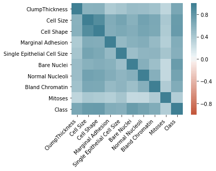

```python
# Check for correlation of variable
# Check for correlation of variable
corr = cancer_df.corr()
ax = sns.heatmap(corr,
    vmin=-1, vmax=1, center=0,
    cmap=sns.diverging_palette(20, 220, n=200),
    square=True)
ax.set_xticklabels(
    ax.get_xticklabels(),
    rotation=45,
    horizontalalignment='right'
);
corr
```

Green means positive, red means negative. The stronger the color, the larger the correlation magnitude

Strong correlations are among below pairs:

1. Cell Shape, Cell Size
2. Normal Nucleoli, Cell Size
3. Cell Size and Class
4. Cell Shape and Class
5. Normal Nucleoli and Class

Weak Correlations are among below mentioned pairs:

1. Normal Nucleoli, Mitoses

```python
# Cell size shows high significance with cell shape,marginal adhesion, single epithelial cell size,bare nuclei, normal nucleoli
# and bland chromatin
# Target variable shows high correlation with most of these variables
```

```python
#Let us check for pair plots
```

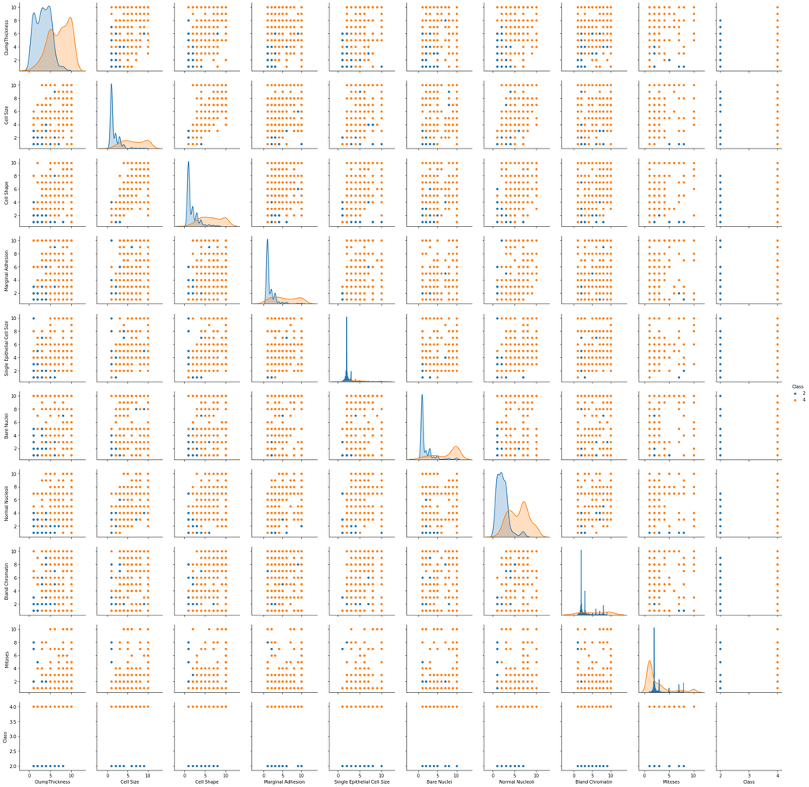

```python
sns.pairplot(cancer_df, hue='Class')
```

###### Relationship between variables shows come correlation.

Mitoses, Normal Nuclie and Clump Thickness are not linearly separable as much as other fields are.

###### Distribution of variables shows most of the values are concentrated on lower side, though range remains same for all that is

###### Between 1 to 10

Majority class is 4

```python
# Relationship between variables shows come correlation.
# Distribution of variables shows most of the values are concentrated on lower side, though range remains same for all that is
# Between 1 to 10
```